# Developmental ToM: cross-task fine-tuning transfer

Each cell is the mean change in log-odds of the correct answer on the **test task** (columns) after fine-tuning on the **train task** (rows), relative to the base model. Every cell is scored on held-out stories (4-fold CV over stories), so each item is tested once per seed. Values are averaged over items, then over seeds. Outlined cells are within-task. `attn_loc` (location attention checks) is evaluated but never trained on.

Correct answers: **fb** = the protagonist’s belief (start location for False Belief, end location for True Belief); **antagonist** = end location in both conditions (the antagonist moved the object); **attn_agent** = the person who placed / moved the object; **attn_loc** = the start / end location.

## Runs found

| Model | Train task | Seeds | Folds per seed |
| --- | --- | --- | --- |
| 13B DPO | fb | 0, 1, 2 | 0, 1, 2, 3 |
| 13B DPO | antagonist | 0, 1, 2 | 0, 1, 2, 3 |
| 13B DPO | attn_agent | 0, 1, 2 | 0, 1, 2, 3 |
| 13B Instruct | fb | 0, 1, 2 | 0, 1, 2, 3 |
| 13B Instruct | antagonist | 0, 1, 2 | 0, 1, 2, 3 |
| 13B Instruct | attn_agent | 0, 1, 2 | 0, 1, 2, 3 |
| 13B Pretrained | fb | 0, 1, 2 | 0, 1, 2, 3 |
| 13B Pretrained | antagonist | 0, 1, 2 | 0, 1, 2, 3 |
| 13B Pretrained | attn_agent | 0, 1, 2 | 0, 1, 2, 3 |
| 13B SFT | fb | 0, 1, 2 | 0, 1, 2, 3 |
| 13B SFT | antagonist | 0, 1, 2 | 0, 1, 2, 3 |
| 13B SFT | attn_agent | 0, 1, 2 | 0, 1, 2, 3 |
| 13B Stage 1 | fb | 0, 1, 2 | 0, 1, 2, 3 |
| 13B Stage 1 | antagonist | 0, 1, 2 | 0, 1, 2, 3 |
| 13B Stage 1 | attn_agent | 0, 1, 2 | 0, 1, 2, 3 |
| 13B Stage 2 | fb | 0, 1, 2 | 0, 1, 2, 3 |
| 13B Stage 2 | antagonist | 0, 1, 2 | 0, 1, 2, 3 |
| 13B Stage 2 | attn_agent | 0, 1, 2 | 0, 1, 2, 3 |
| 7B DPO | fb | 0, 1, 2 | 0, 1, 2, 3 |
| 7B DPO | antagonist | 0, 1, 2 | 0, 1, 2, 3 |
| 7B DPO | attn_agent | 0, 1, 2 | 0, 1, 2, 3 |
| 7B Instruct | fb | 0, 1, 2 | 0, 1, 2, 3 |
| 7B Instruct | antagonist | 0, 1, 2 | 0, 1, 2, 3 |
| 7B Instruct | attn_agent | 0, 1, 2 | 0, 1, 2, 3 |
| 7B Pretrained | fb | 0, 1, 2 | 0, 1, 2, 3 |
| 7B Pretrained | antagonist | 0, 1, 2 | 0, 1, 2, 3 |
| 7B Pretrained | attn_agent | 0, 1, 2 | 0, 1, 2, 3 |
| 7B SFT | fb | 0, 1, 2 | 0, 1, 2, 3 |
| 7B SFT | antagonist | 0, 1, 2 | 0, 1, 2, 3 |
| 7B SFT | attn_agent | 0, 1, 2 | 0, 1, 2, 3 |
| 7B Stage 1 | fb | 0, 1, 2 | 0, 1, 2, 3 |
| 7B Stage 1 | antagonist | 0, 1, 2 | 0, 1, 2, 3 |
| 7B Stage 1 | attn_agent | 0, 1, 2 | 0, 1, 2, 3 |
| 7B Stage 2 | fb | 0, 1, 2 | 0, 1, 2, 3 |
| 7B Stage 2 | antagonist | 0, 1, 2 | 0, 1, 2, 3 |
| 7B Stage 2 | attn_agent | 0, 1, 2 | 0, 1, 2, 3 |

Log-odds units: natural log. If a run is incomplete (not all 4 folds), a cell only covers some stories, so compare cells with care.

## Summary figure: accuracy by training condition

Accuracy on fb and antagonist, by condition, for the base model and after fine-tuning on each task. One figure per model size. Small faint points are individual checkpoints (training stages), each averaged over seeds. Large points are the mean across those checkpoints, with ±1 SE across checkpoints.

### OLMo 2 7B

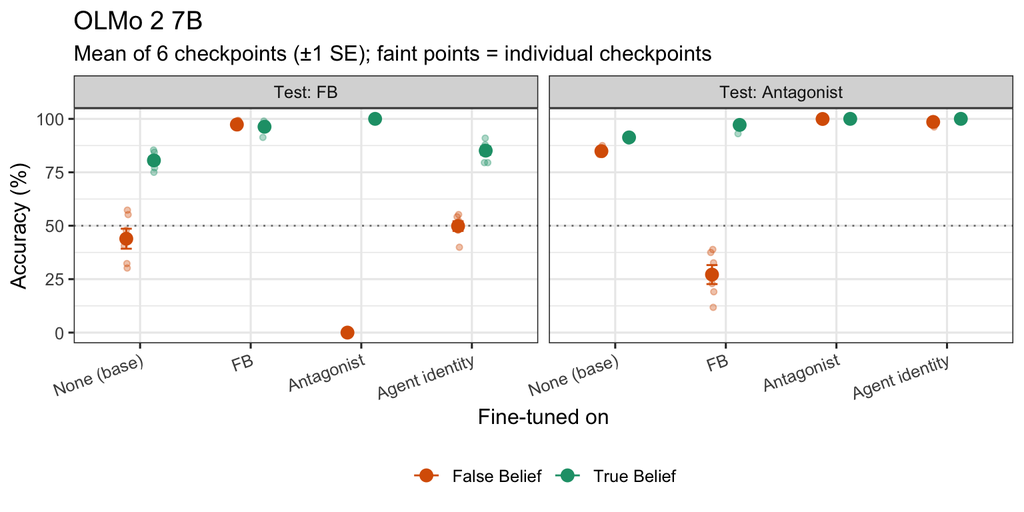

### OLMo 2 13B

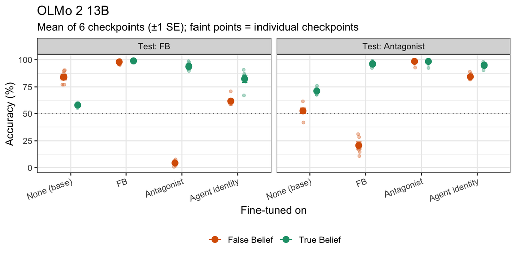

### All sizes in one figure

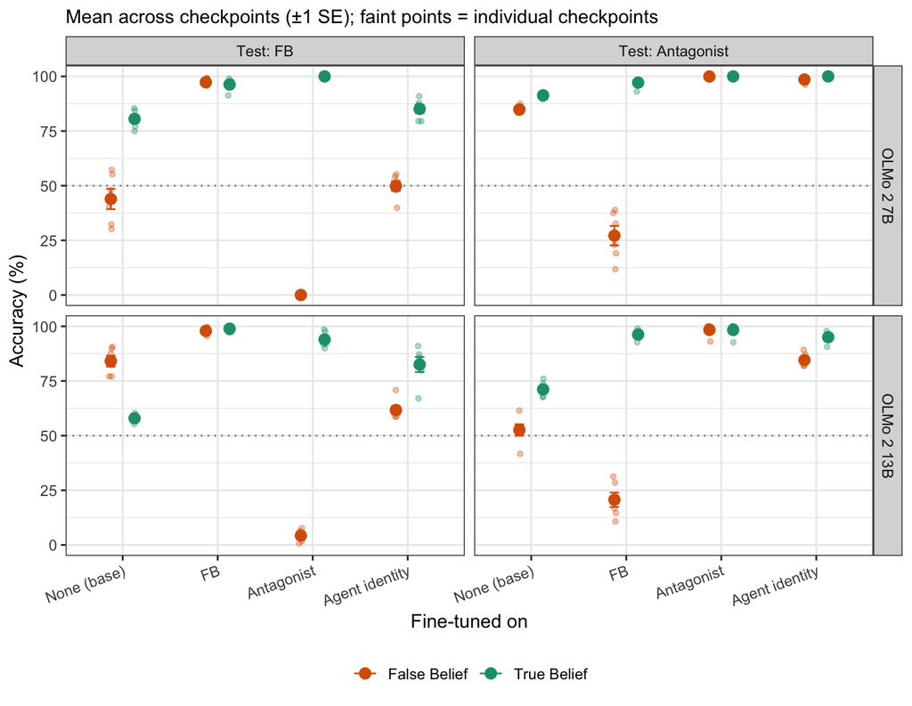

## Trade-off: change on fb vs. change on antagonist

Each training condition as two numbers: the change in accuracy on **fb** (x) and on **antagonist** (y), relative to the base model, using False Belief items only. Points in the top-left or bottom-right helped one task at the expense of the other. Large points are the mean across checkpoints (±1 SE in both directions); faint points are individual checkpoints. One panel per model size.

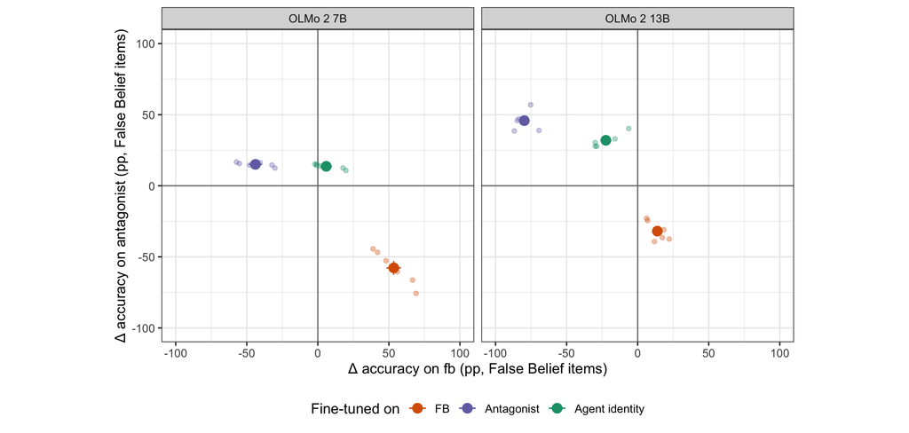

Mean change from base, False Belief items (SE across checkpoints)

| Size | Fine-tuned on | Δ fb (pp) | Δ antagonist (pp) |
| --- | --- | --- | --- |
| 7B | FB | +53 (5) | -58 (5) |
| 7B | Antagonist | -44 (5) | +15 (1) |
| 7B | Agent identity | +6 (4) | +14 (1) |
| 13B | FB | +14 (3) | -32 (3) |
| 13B | Antagonist | -80 (3) | +46 (3) |
| 13B | Agent identity | -22 (4) | +32 (2) |

## Heatmaps by model

### 7B Stage 1

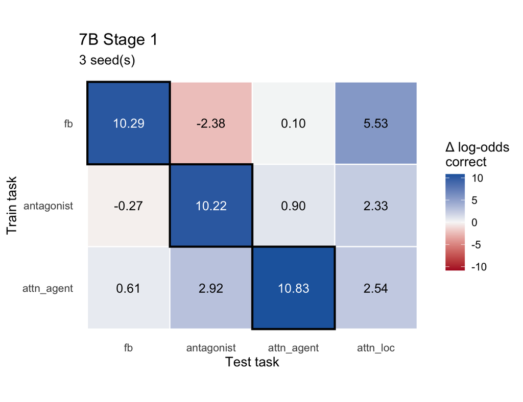

### 7B Stage 2

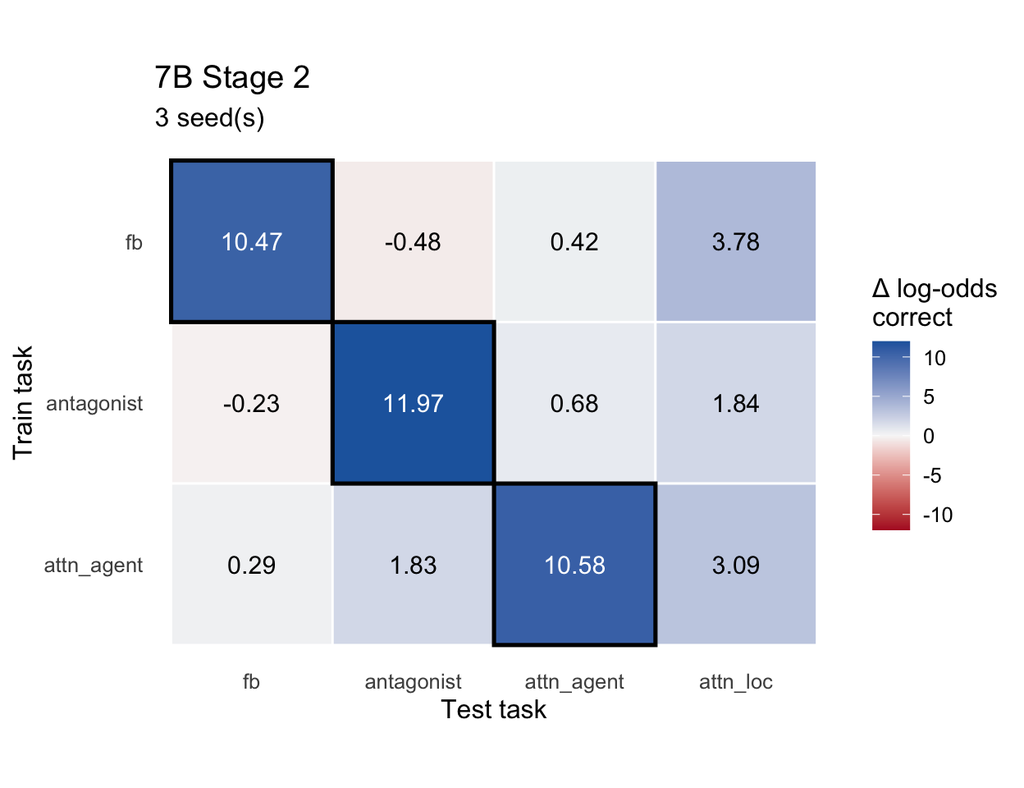

### 7B Pretrained

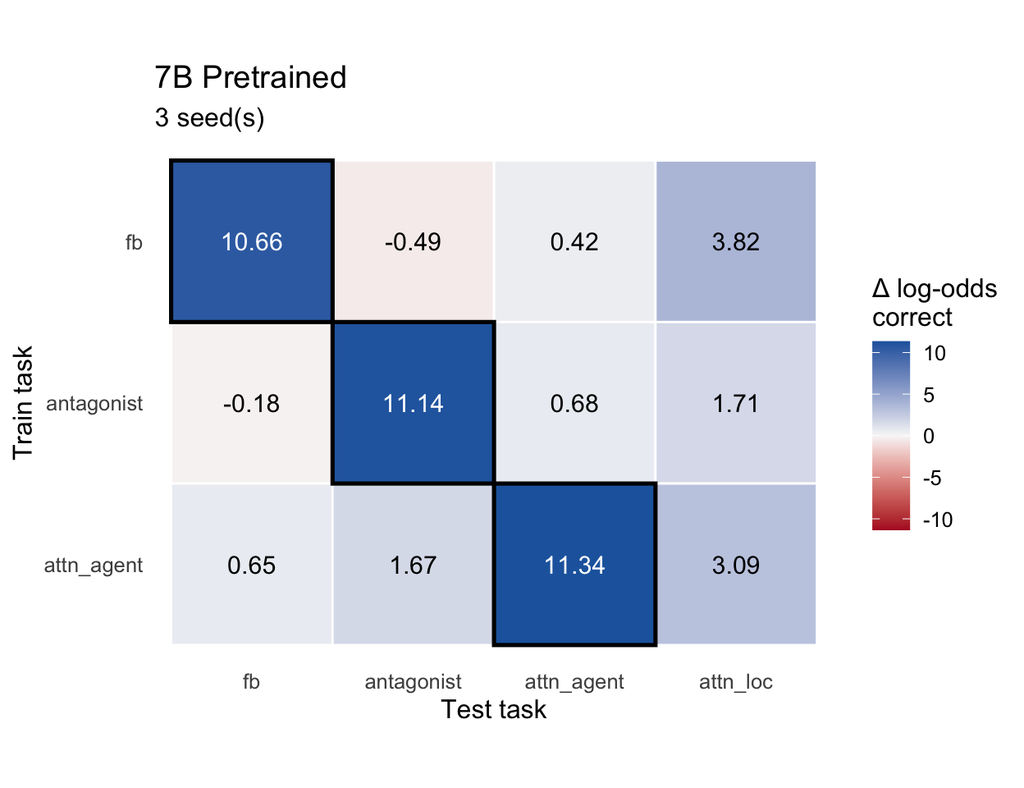

### 7B SFT

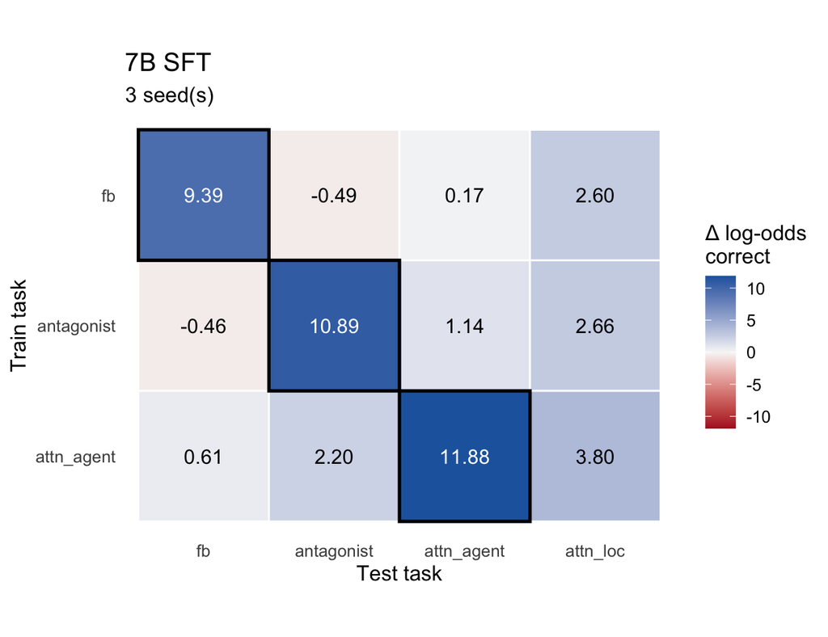

### 7B DPO

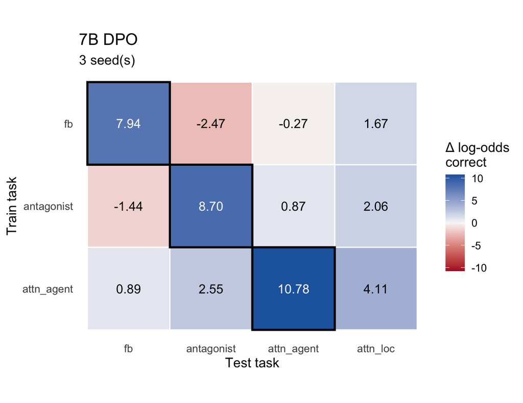

### 7B Instruct

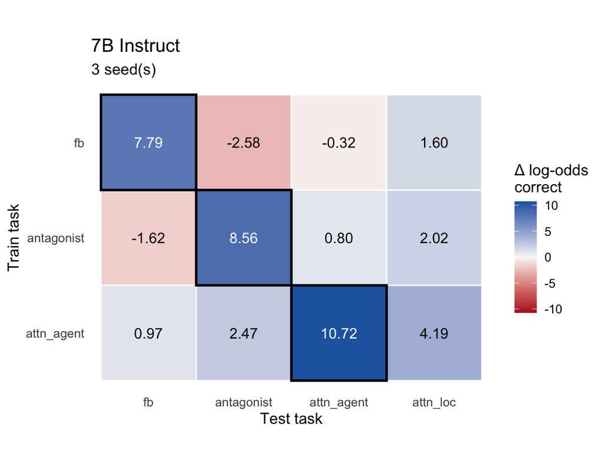

### 13B Stage 1

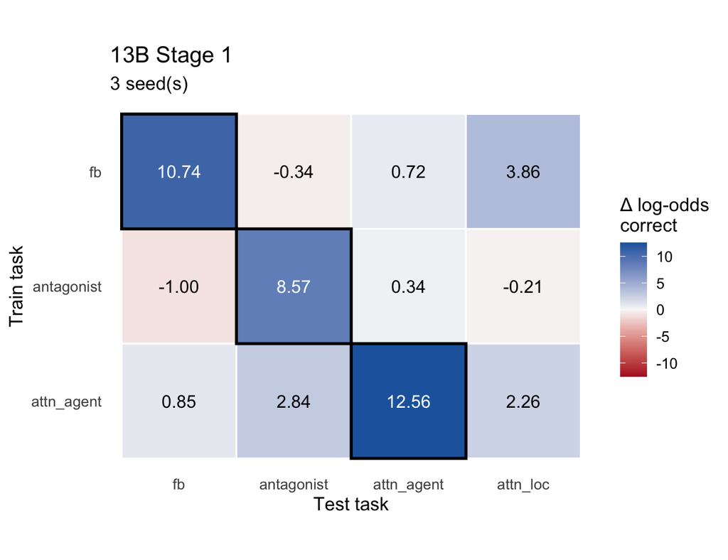

### 13B Stage 2

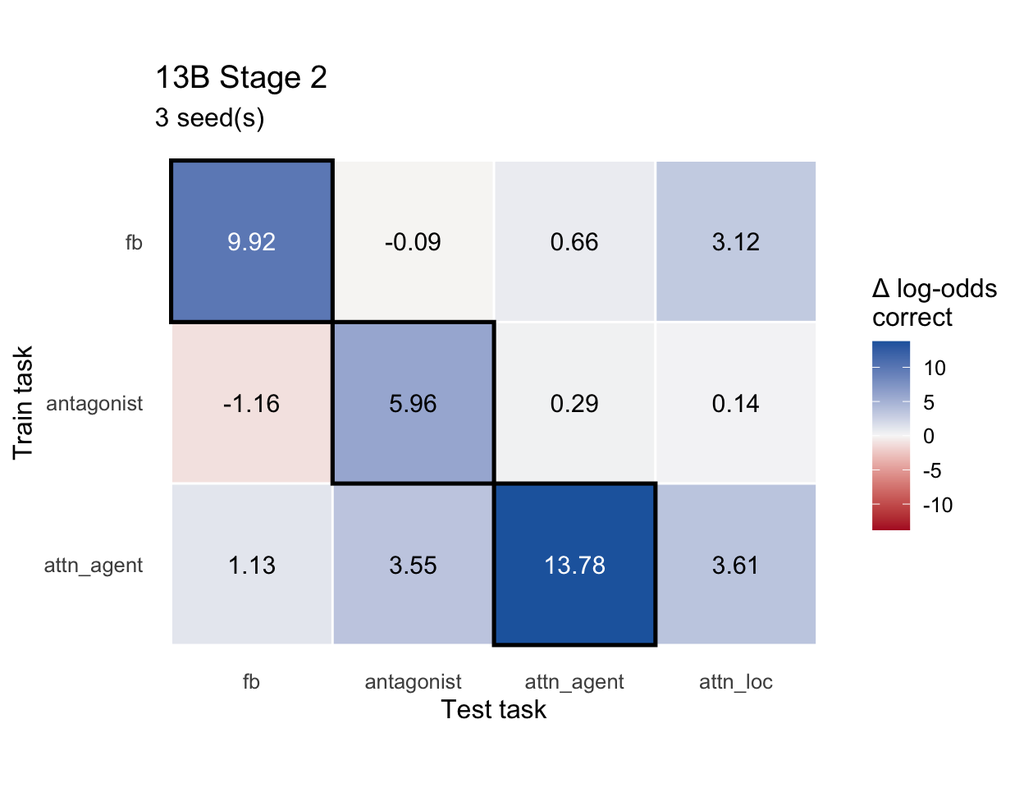

### 13B Pretrained

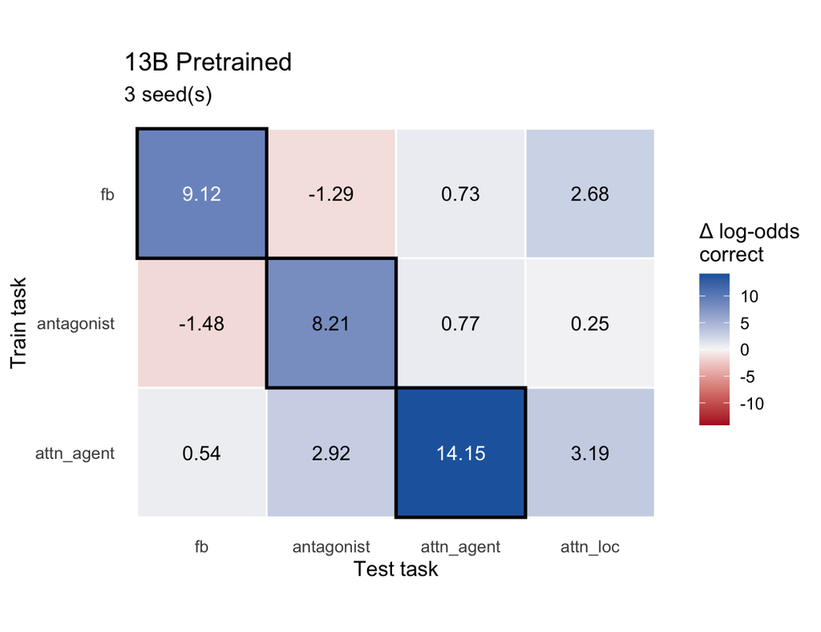

### 13B SFT

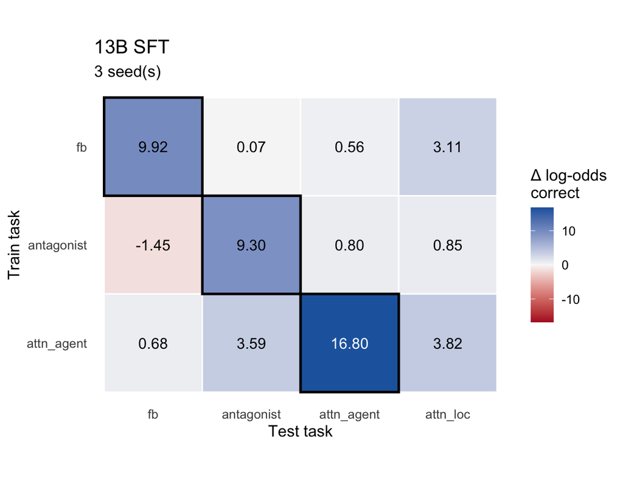

### 13B DPO

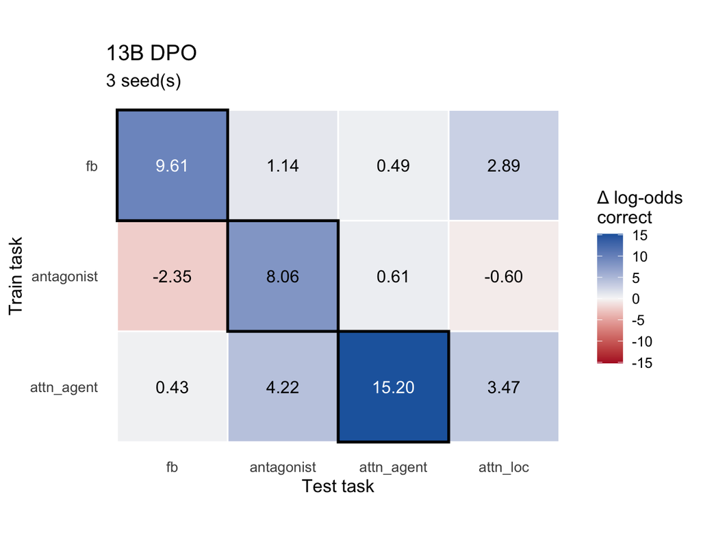

### 13B Instruct

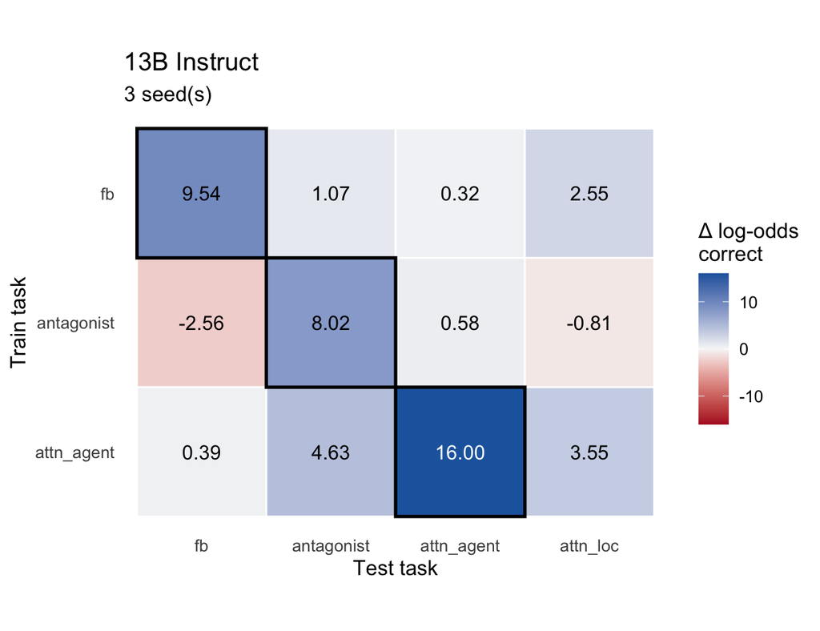

## All models together

Shared color scale, so cells can be compared across models and checkpoints.

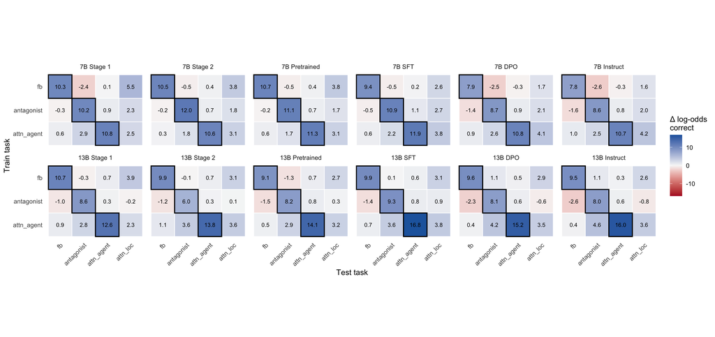

## Gain by condition

Mean gain for each condition of each test task (fb and antagonist: False vs. True Belief; attention checks: question type). Error bars are ±1 SE across seeds. Orange marks answers that match the protagonist’s outdated view (False Belief, original location); green marks answers that match current reality (True Belief, final location).

How to read a shift toward one location:

- **fb**: a general shift toward the end location shows up as False Belief down and True Belief up. If both go up, the change depends on the condition.
- **antagonist**: the correct answer is the end location in *both* conditions, so a general shift toward the end location makes both go up. Compare with fb to tell real agent tracking apart from that shift.

### 7B Stage 1

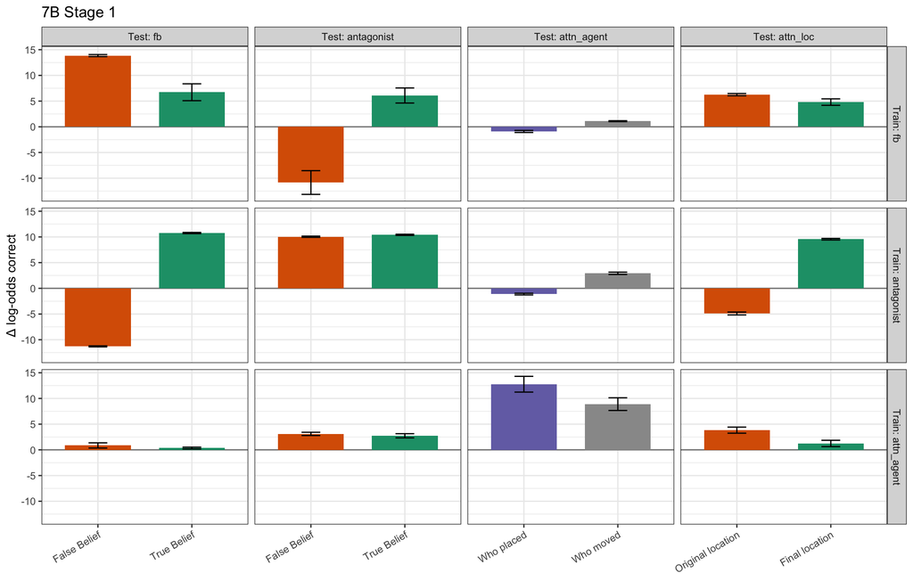

### 7B Stage 2

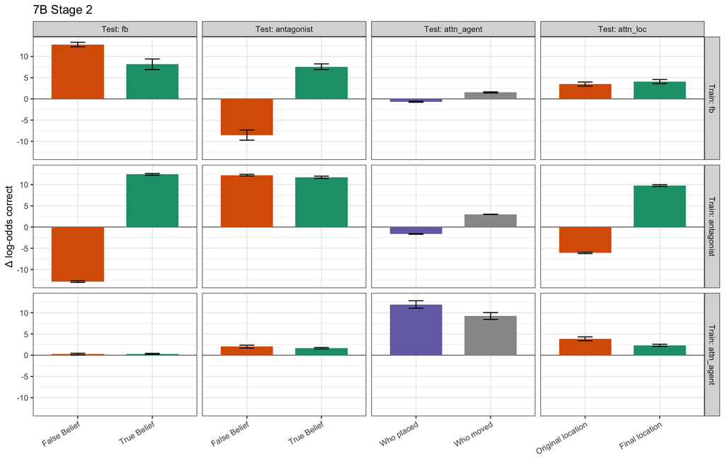

### 7B Pretrained

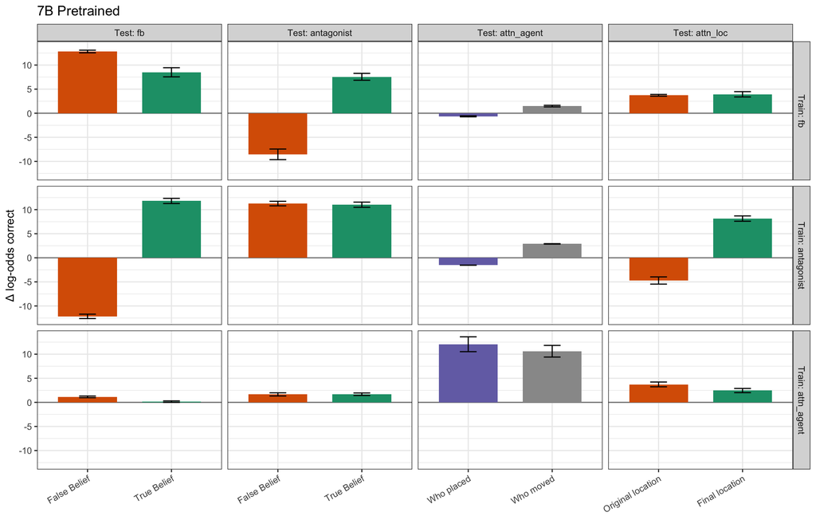

### 7B SFT

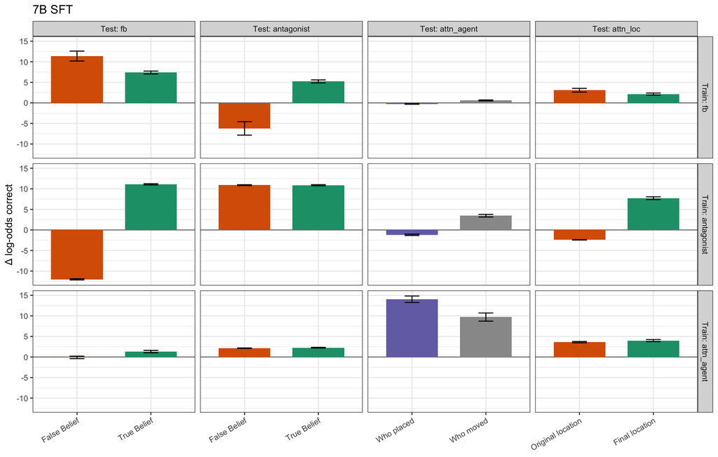

### 7B DPO

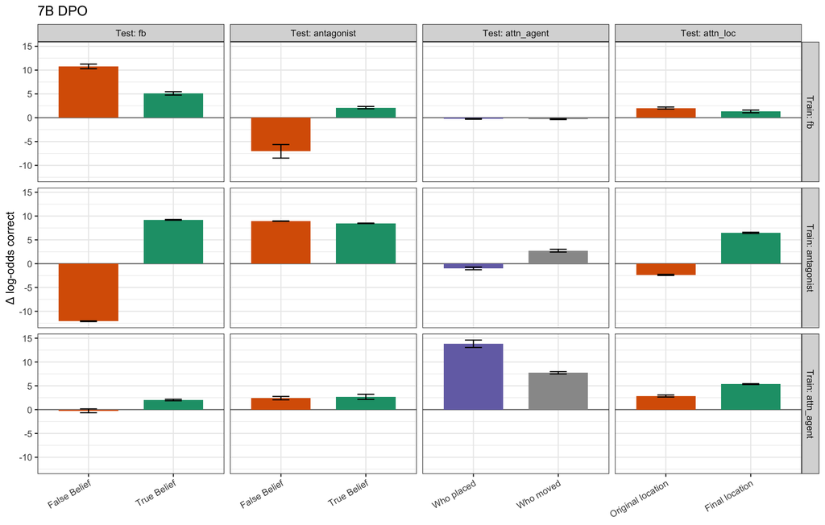

### 7B Instruct

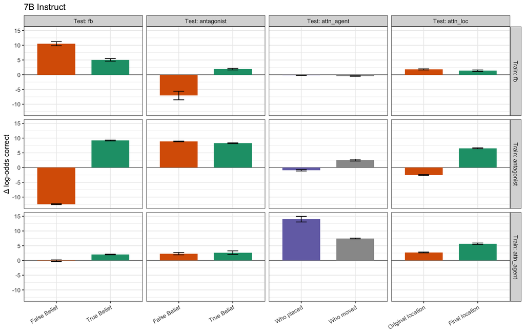

### 13B Stage 1

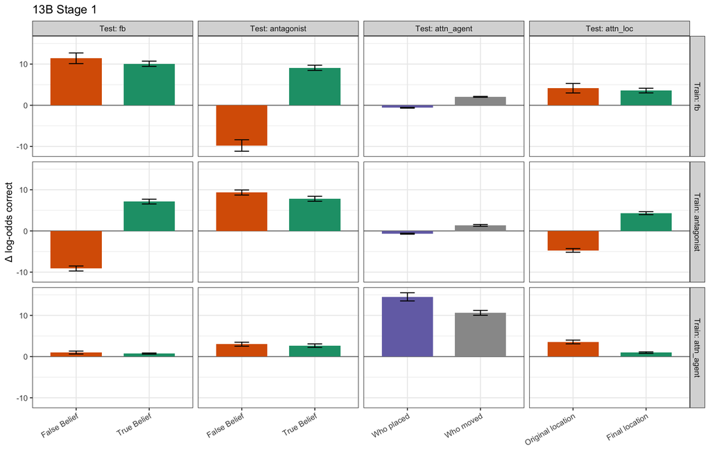

### 13B Stage 2

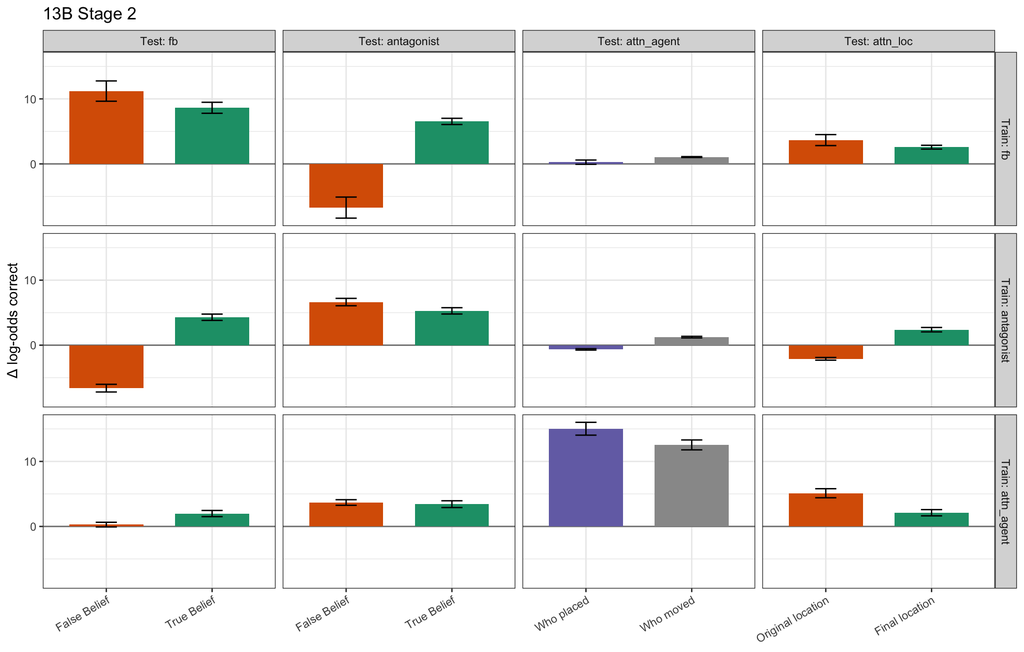

### 13B Pretrained

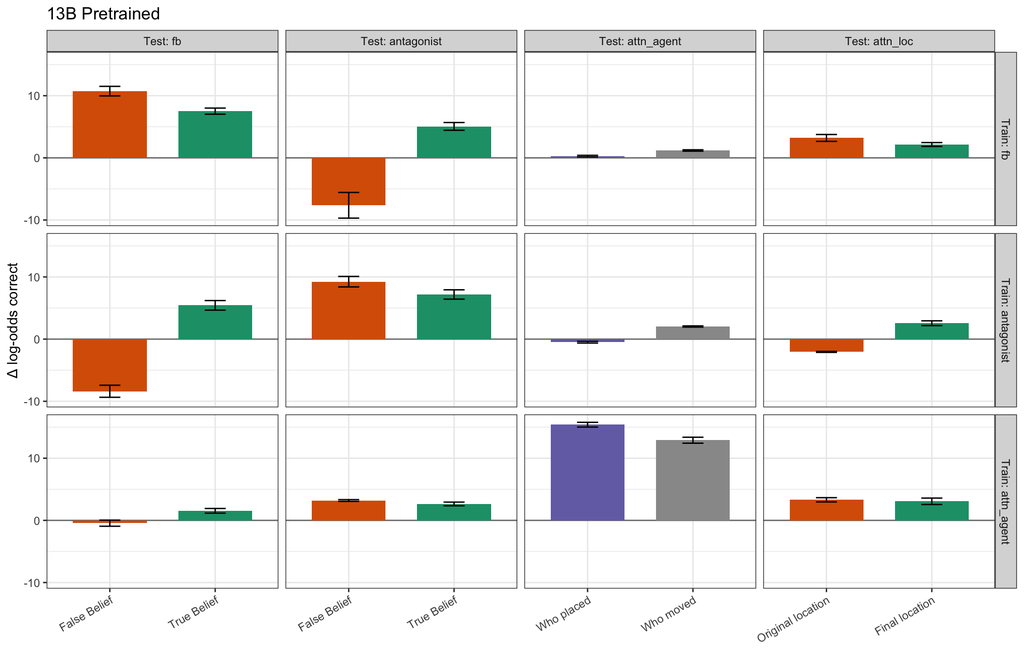

### 13B SFT

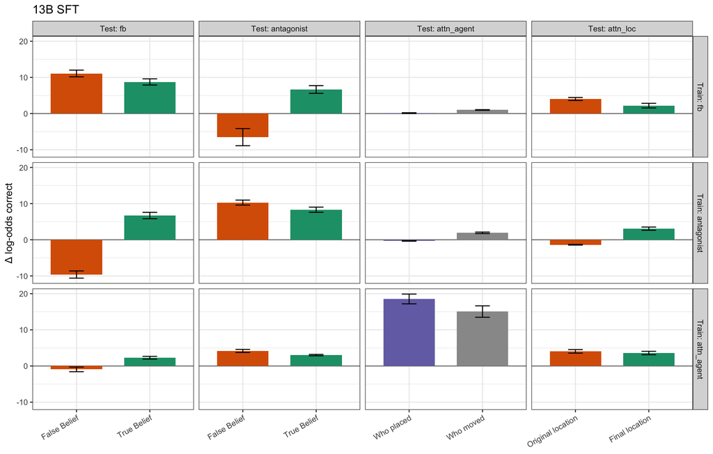

### 13B DPO

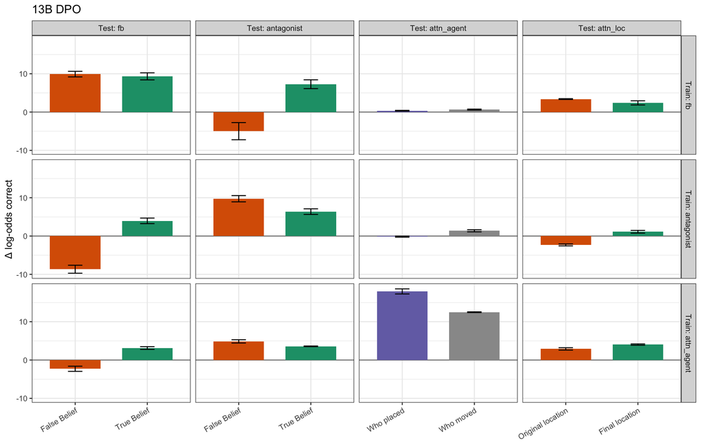

### 13B Instruct

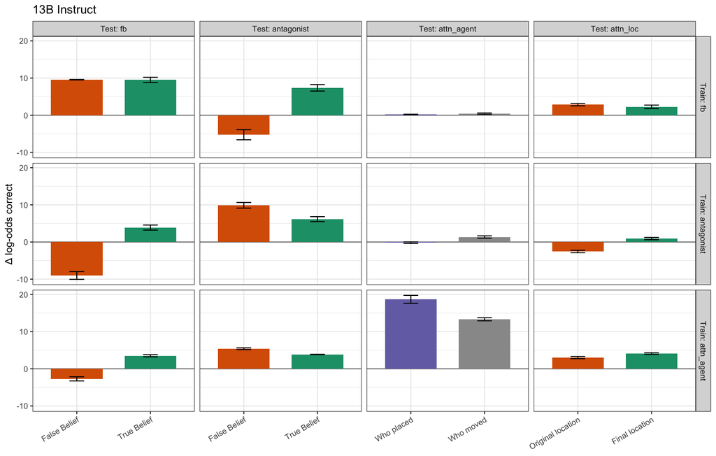

## Attention checks by passage type

Gain on each attention-check question, split by whether it was asked about a False Belief or a True Belief passage. If a fine-tuned model answers based on the type of story rather than the question, it should favor the original location (and the person who placed the object) on False Belief passages, and the final location (and the person who moved it) on True Belief passages, whatever the question asks.

### 7B Stage 1

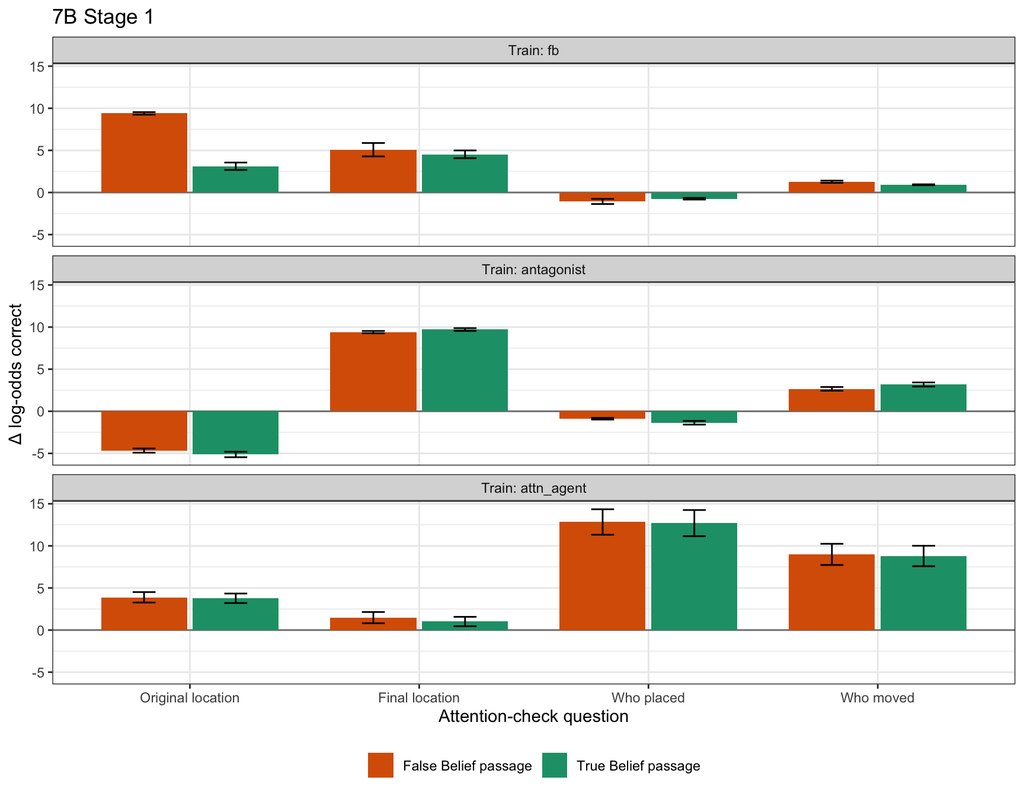

### 7B Stage 2

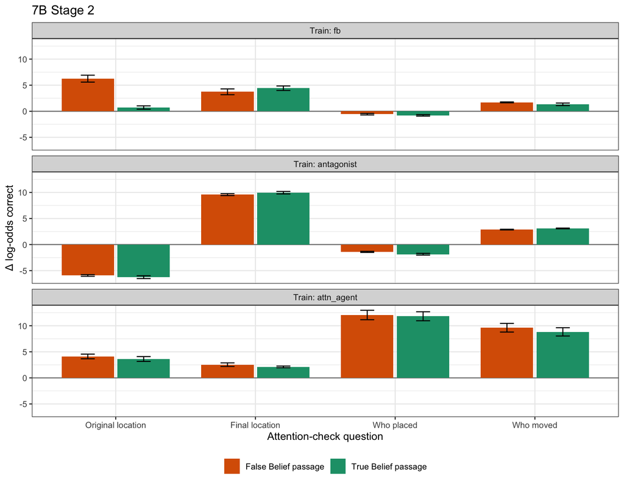